# lab2-partial-solutions

## Basic solutions

The following document is a basic guide to the solutions for the second lab with limited exposition. Actual solutions submitted by students should have more explanation and interpretation of results.

## Toronto Bike Share

### Questions

Use the 2016 Q3, 2016 Q4, and 2017 Toronto Bikeshare ridership data available [here](https://open.toronto.ca/dataset/bike-share-toronto-ridership-data/) the questions below.

Station information, including real time data, is available [here](https://open.toronto.ca/dataset/bike-share-toronto/).

A [blog post](https://towardsdatascience.com/exploring-toronto-bike-share-ridership-using-python-3dc87d35cb62) was written on the 2017 data set.

Create either an Rmarkdown or Jupyter notebook to answer the questions below. In all of the questions below interpret your results, and identify limitations.

1. Read through the questions below.
   1. Create a brief plan of the variables that you plan to use to answer these questions ii.explore the variables using quantitative and visual methods
   2. rectify any inconsistencies you find through exploration.

The plan is to try to find variables associated with trip duration and trip length. The main variables we will look at include date variables (day, week, month, etc…), station information, weather (temperature and precipitation), and member type.

Loading the data from the individual files

```r
# load the required libraries ---------------------------------------------

library(tidyverse)
library(lubridate)
library(rvest)
library(httr)
library(fuzzyjoin)

# read in the data --------------------------------------------------------
path <- file.path(here::here(), "lab3_data")
# 2016
bike_2016_q3 <- read_csv(glue::glue('{path}/bikeshare-ridership-2016-q3.csv'))
bike_2016_q4 <- read_csv(glue::glue('{path}/bikeshare-ridership-2016-q4.csv'))
# 2017
bike_2017_q1 <- read_csv(glue::glue('{path}//Bikeshare Ridership (2017 Q1).csv'))
bike_2017_q2 <- read_csv(glue::glue('{path}/Bikeshare Ridership (2017 Q2).csv'))
bike_2017_q3 <- read_csv(glue::glue('{path}/Bikeshare Ridership (2017 Q3).csv'))
bike_2017_q4 <- read_csv(glue::glue('{path}/Bikeshare Ridership (2017 Q4).csv'))
```

Fixing the timestamps and merging the data together

```r
#   -----------------------------------------------------------------------
# convert dates -----------------------------------------------------------
bike_2016_q3 <- bike_2016_q3 %>%
  mutate(trip_start_time = mdy_hm(trip_start_time),
         trip_stop_time = mdy_hm(trip_stop_time))%>%
  mutate(trip_start_time = lubridate::with_tz(trip_start_time, tzone = "EST"),
         trip_stop_time = lubridate::with_tz(trip_stop_time, tzone = "EST"))

bike_2016_q4 <- bike_2016_q4 %>%
  mutate(trip_start_time = dmy_hm(trip_start_time),
         trip_stop_time = dmy_hm(trip_stop_time))%>%
  mutate(trip_start_time = lubridate::with_tz(trip_start_time, tzone = "EST"),
         trip_stop_time = lubridate::with_tz(trip_stop_time, tzone = "EST"))

bike_2017_q1 <- bike_2017_q1 %>%
  mutate(trip_start_time = dmy_hm(trip_start_time),
         trip_stop_time = dmy_hm(trip_stop_time)) %>%
  mutate(trip_start_time = lubridate::with_tz(trip_start_time, tzone = "EST"),
         trip_stop_time = lubridate::with_tz(trip_stop_time, tzone = "EST"))

bike_2017_q2 <- bike_2017_q2 %>%
  mutate(trip_start_time = dmy_hm(trip_start_time),
         trip_stop_time = dmy_hm(trip_stop_time)) %>%
  mutate(trip_start_time = lubridate::with_tz(trip_start_time, tzone = "EST"),
         trip_stop_time = lubridate::with_tz(trip_stop_time, tzone = "EST"))

bike_2017_q3 <- bike_2017_q3 %>%
  mutate(trip_start_time = mdy_hm(trip_start_time),
         trip_stop_time = mdy_hm(trip_stop_time))

bike_2017_q4 <- bike_2017_q4 %>%
  mutate(trip_start_time = mdy_hms(trip_start_time),
         trip_stop_time = mdy_hms(trip_stop_time))
#   -----------------------------------------------------------------------
#   -----------------------------------------------------------------------


# bind the data back together ---------------------------------------------
bike <- bike_2016_q3 %>%
  bind_rows(bike_2016_q4) %>%
  bind_rows(bike_2017_q1) %>%
  bind_rows(bike_2017_q2) %>%
  bind_rows(bike_2017_q3) %>%
  bind_rows(bike_2017_q4)
```

Filtering out some bad timestamps and outliers in the trip duration variable

```r
# first trip start time
min(bike$trip_start_time, na.rm = T)
```

```
## [1] "2000-01-01 14:40:00 UTC"
```

```r
# first trip end time
min(bike$trip_stop_time, na.rm = T)
```

```
## [1] "2000-01-01 15:44:00 UTC"
```

```r
# last trip start time
max(bike$trip_start_time, na.rm = T)
```

```
## [1] "2017-12-31 23:49:41 UTC"
```

```r
# last trip end time
max(bike$trip_stop_time, na.rm = T)
```

```
## [1] "2018-01-01 00:11:40 UTC"
```

```r
# filter out improper dates
nrow(bike)
```

```
## [1] 2011407
```

```r
bike <- bike %>%
  filter(trip_start_time >= ymd_hms('2016-07-01 00:00:00'),
         trip_stop_time >= ymd_hms('2016-07-01 00:00:00'),
         trip_start_time < ymd_hms('2018-01-01 00:00:00'),
         trip_stop_time < ymd_hms('2018-01-01 00:00:00'))
nrow(bike)
```

```
## [1] 2011404
```

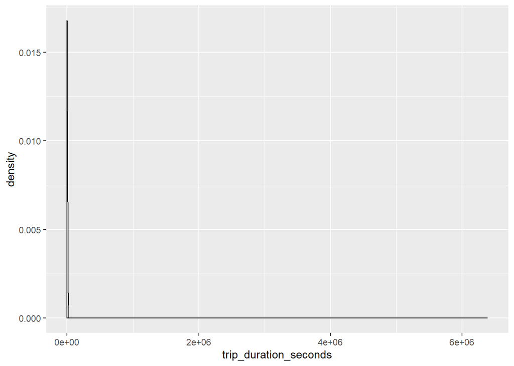

```r
# distribution of trip duration
bike %>%
  ggplot(aes(trip_duration_seconds)) +
  geom_density()
```

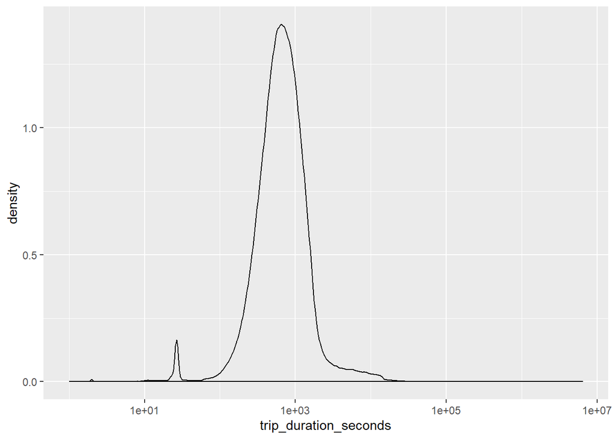

```r
# log transformed
bike %>%
  ggplot(aes(trip_duration_seconds)) +
  geom_density() +
  scale_x_log10()
```

```r
summary(bike$trip_duration_seconds)
```

```
##    Min. 1st Qu.  Median    Mean 3rd Qu.    Max.
##       1     418     653     981    1007 6382030
```

```r
# how many less than 1 minute
sum(bike$trip_duration_seconds <= 60)
```

```
## [1] 29450
```

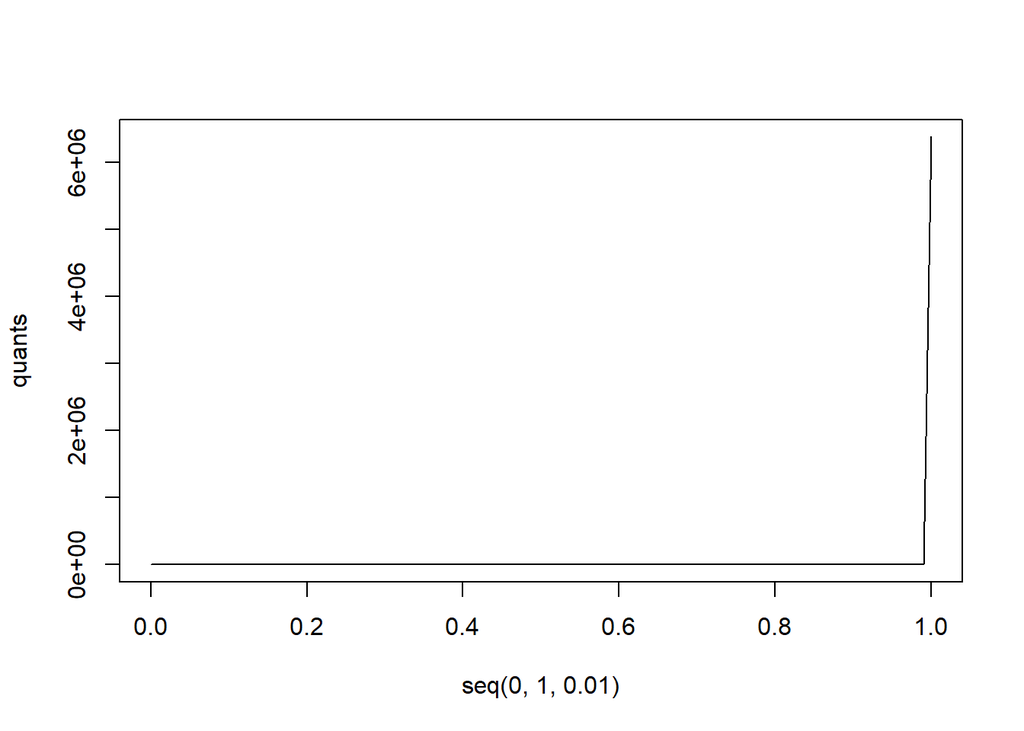

```r
# filter out trips less than a minute
bike <- bike %>%
  filter(trip_duration_seconds > 60)

quants <- quantile(bike$trip_duration_seconds, probs = seq(0, 1, .01))

plot(seq(0, 1, .01), quants, type = "l")
```

```r
print(quants)
```

```
##      0%      1%      2%      3%      4%      5%      6%      7%      8%      9%
##      61     129     160     183     202     218     233     247     259     272
##     10%     11%     12%     13%     14%     15%     16%     17%     18%     19%
##     283     294     305     315     325     335     345     354     364     373
##     20%     21%     22%     23%     24%     25%     26%     27%     28%     29%
##     382     392     401     410     419     428     437     445     454     463
##     30%     31%     32%     33%     34%     35%     36%     37%     38%     39%
##     472     480     489     498     507     516     525     534     543     552
##     40%     41%     42%     43%     44%     45%     46%     47%     48%     49%
##     562     571     580     590     599     609     619     629     640     650
##     50%     51%     52%     53%     54%     55%     56%     57%     58%     59%
##     660     671     682     693     705     716     728     740     752     765
##     60%     61%     62%     63%     64%     65%     66%     67%     68%     69%
##     778     791     804     817     831     846     861     876     891     907
##     70%     71%     72%     73%     74%     75%     76%     77%     78%     79%
##     923     940     958     976     995    1014    1034    1055    1077    1101
##     80%     81%     82%     83%     84%     85%     86%     87%     88%     89%
##    1125    1151    1178    1207    1238    1271    1306    1344    1386    1432
##     90%     91%     92%     93%     94%     95%     96%     97%     98%     99%
##    1484    1544    1613    1700    1823    2018    2377    3131    4675    7821
##    100%
## 6382030
```

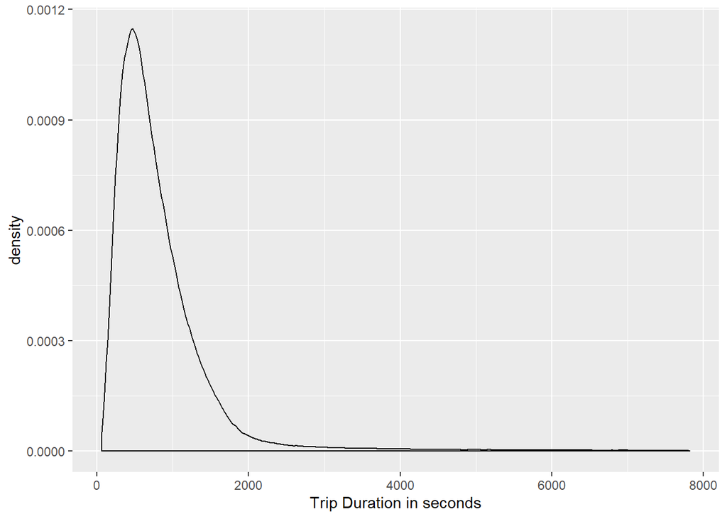

```r
# We are going to remove everything above the 99th percentile (2.2 hours)

bike <- bike %>%
  filter(trip_duration_seconds < quants[100])

bike %>%
  ggplot(aes(trip_duration_seconds)) +
  geom_density() +
  xlab("Trip Duration in seconds")
```

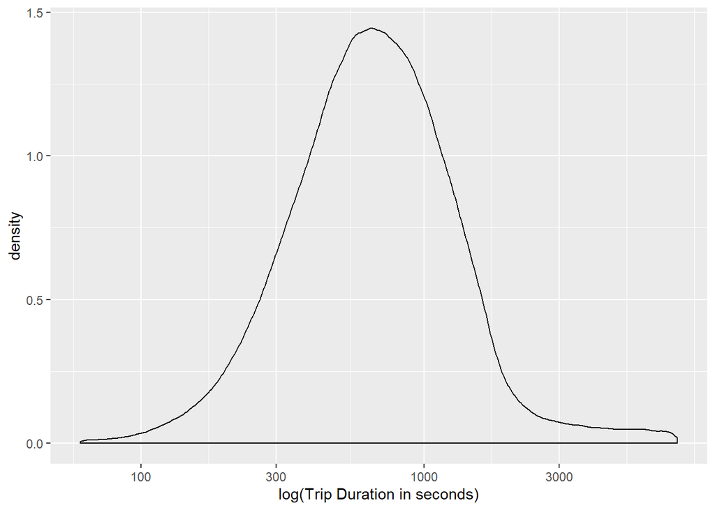

```r
# log transformed
bike %>%
  ggplot(aes(trip_duration_seconds)) +
  geom_density() +
  scale_x_log10() +
  xlab("log(Trip Duration in seconds)")
```

### Basic descriptive statistics

```r
glimpse(bike)
```

```
## Observations: 1,962,131
## Variables: 20
## $ trip_id               <dbl> 53279, 53394, 58314, 60784, 102861, 106810, 1...
## $ trip_start_time       <dttm> 2016-07-09 01:03:00, 2016-07-09 02:15:00, 20...
## $ trip_stop_time        <dttm> 2016-07-09 01:15:00, 2016-07-09 02:22:00, 20...
## $ trip_duration_seconds <dbl> 714, 417, 1904, 784, 658, 1163, 694, 501, 363...
## $ from_station_name     <chr> "Dundas St E / Regent Park Blvd", "Riverdale ...
## $ to_station_name       <chr> "Danforth Ave / Ellerbeck St", "Dundas St E /...
## $ user_type             <chr> "Member", "Member", "Member", "Member", "Memb...
## $ from_station_id       <lgl> NA, NA, NA, NA, NA, NA, NA, NA, NA, NA, NA, N...
## $ to_station_id         <lgl> NA, NA, NA, NA, NA, NA, NA, NA, NA, NA, NA, N...
## $ from_id               <dbl> 7100, 7097, 7100, 7033, 7100, 7090, 7100, 703...
## $ from_lat              <dbl> 43.66021, 43.67117, 43.66021, 43.64561, 43.66...
## $ from_lon              <dbl> -79.36128, -79.35470, -79.36128, -79.38039, -...
## $ from_name             <lgl> NA, NA, NA, NA, NA, NA, NA, NA, NA, NA, NA, N...
## $ dist                  <lgl> NA, NA, NA, NA, NA, NA, NA, NA, NA, NA, NA, N...
## $ to_id                 <dbl> 7095, 7100, 7136, 7100, 7033, 7065, 7033, 701...
## $ to_lat                <dbl> 43.67708, 43.66021, 43.64063, 43.66021, 43.64...
## $ to_lon                <dbl> -79.35667, -79.36128, -79.43584, -79.36128, -...
## $ to_name               <lgl> NA, NA, NA, NA, NA, NA, NA, NA, NA, NA, NA, N...
## $ dist_to               <lgl> NA, NA, NA, NA, NA, NA, NA, NA, NA, NA, NA, N...
## $ distance              <dbl> 1914.109, 1330.375, 6389.063, 2238.326, 2238....
```

```r
summary(bike)
```

```
##     trip_id        trip_start_time               trip_stop_time
##  Min.   :  24008   Min.   :2016-07-01 00:00:00   Min.   :2016-07-01 00:07:00
##  1st Qu.: 625462   1st Qu.:2016-11-15 13:03:00   1st Qu.:2016-11-15 13:13:30
##  Median :1216708   Median :2017-06-24 19:29:00   Median :2017-06-24 19:53:00
##  Mean   :1214351   Mean   :2017-05-01 19:55:05   Mean   :2017-05-01 20:09:01
##  3rd Qu.:1807012   3rd Qu.:2017-09-11 17:25:30   3rd Qu.:2017-09-11 17:39:00
##  Max.   :2383646   Max.   :2017-12-31 23:49:41   Max.   :2017-12-31 23:58:24
##  trip_duration_seconds from_station_name  to_station_name     user_type
##  Min.   :  61.0        Length:1962131     Length:1962131     Length:1962131
##  1st Qu.: 425.0        Class :character   Class :character   Class :character
##  Median : 655.0        Mode  :character   Mode  :character   Mode  :character
##  Mean   : 835.8
##  3rd Qu.:1000.0
##  Max.   :7820.0
##  from_station_id to_station_id     from_id        from_lat        from_lon
##  Mode:logical    Mode:logical   Min.   :7000   Min.   :43.62   Min.   :-79.48
##  NA's:1962131    NA's:1962131   1st Qu.:7030   1st Qu.:43.65   1st Qu.:-79.40
##                                 Median :7065   Median :43.65   Median :-79.39
##                                 Mean   :7101   Mean   :43.65   Mean   :-79.39
##                                 3rd Qu.:7156   3rd Qu.:43.66   3rd Qu.:-79.38
##                                 Max.   :7656   Max.   :43.69   Max.   :-79.29
##  from_name        dist             to_id          to_lat          to_lon
##  Mode:logical   Mode:logical   Min.   :7000   Min.   :43.62   Min.   :-79.48
##  NA's:1962131   TRUE:76110     1st Qu.:7030   1st Qu.:43.65   1st Qu.:-79.40
##                 NA's:1886021   Median :7064   Median :43.65   Median :-79.39
##                                Mean   :7100   Mean   :43.65   Mean   :-79.39
##                                3rd Qu.:7155   3rd Qu.:43.66   3rd Qu.:-79.38
##                                Max.   :7656   Max.   :43.69   Max.   :-79.29
##  to_name        dist_to           distance
##  Mode:logical   Mode:logical   Min.   :    0.0
##  NA's:1962131   TRUE:74564     1st Qu.:  946.9
##                 NA's:1887567   Median : 1504.2
##                                Mean   : 1724.5
##                                3rd Qu.: 2262.4
##                                Max.   :12718.4
```

```r
# basic descriptive statistics
cat("number of rows:", nrow(bike))
```

```
## number of rows: 1962131
```

```r
cat("number of columns:", nrow(bike))
```

```
## number of columns: 1962131
```

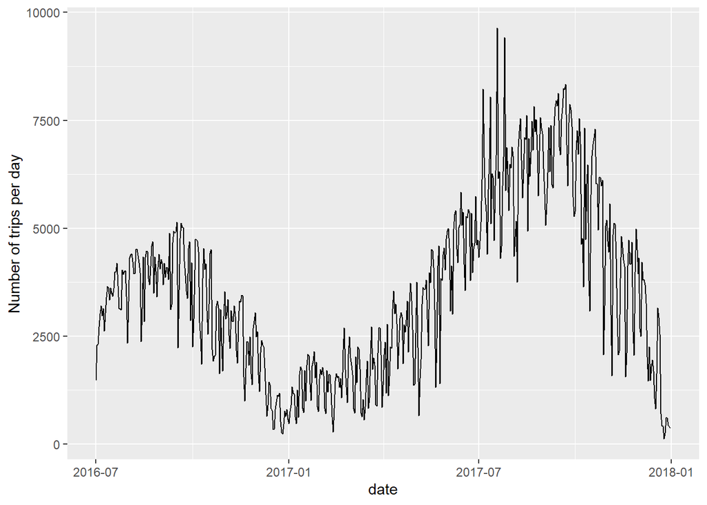

```r
#trips per day over time

bike %>%
  count(date = as_date(trip_start_time)) %>%
  ggplot(aes(date, n)) +
  geom_line() +
  ylab("Number of trips per day")
```

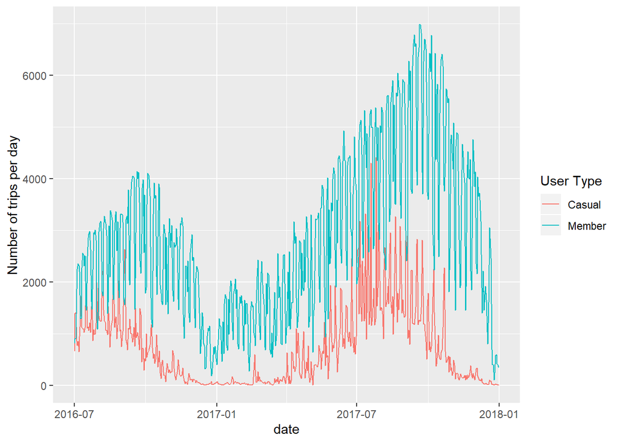

```r
bike %>%
  count(date = as_date(trip_start_time), user_type) %>%
  ggplot(aes(date, n, color = user_type)) +
  geom_line() +
  ylab("Number of trips per day") +
  labs(color = "User Type")
```

### Trip duration by starting location

```r
station_summary <- bike %>%
  group_by(from_station_name) %>%
  summarize(n = n(),
            median_trip_duration = median(trip_duration_seconds/60),
            q25_trip_duration = round(quantile(trip_duration_seconds/60, .25), 3),
            q75_trip_duration = round(quantile(trip_duration_seconds/60, .75), 3))

DT::datatable(station_summary, caption = "Summary of trip durations by station",
              options = list(scrollX = T))
```

|  | from_station_name | n | median_trip_duration | q25_trip_duration | q75_trip_duration |
| --- | --- | --- | --- | --- | --- |
| 1 | 111 Bond St (North of Dundas St E) - SMART | 703 | 8.58333333333333 | 6.408 | 12.125 |
| 2 | 161 Bleecker St (South of Wellesley) | 8569 | 14.05 | 9.533 | 21.2 |
| 3 | 25 York St (ACC/Union Station South) | 10331 | 11.25 | 7.3 | 16.117 |
| 4 | 424 Wellington St W | 2692 | 8.3 | 6.267 | 13.367 |
| 5 | 424 Wellington St. W | 8215 | 9.73333333333333 | 6.9 | 14.783 |
| 6 | 51 Parliament St | 6962 | 11 | 7.667 | 17.433 |
| 7 | 519 Church St - SMART | 1971 | 8.75 | 5.075 | 13.258 |
| 8 | 80 Clinton St (North of College) | 4451 | 12.4333333333333 | 8.15 | 17.267 |
| 9 | Adelaide St W / Bay St - SMART | 3078 | 10.1666666666667 | 6.883 | 14.517 |
| 10 | Augusta Ave / Denison Sq | 11889 | 12.45 | 8.283 | 18.867 |

[output cut: 280 more lines]

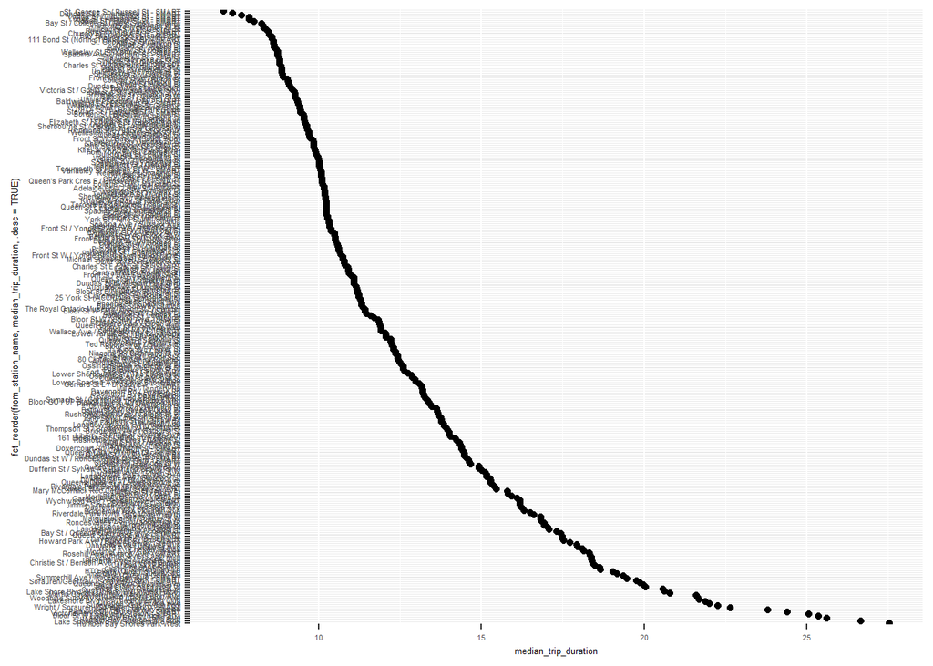

```r
 station_summary %>%
   ggplot(aes(fct_reorder(from_station_name,
                          median_trip_duration, .desc = TRUE),
              median_trip_duration)) +
   geom_point() +
   coord_flip() +
   theme(text = element_text(size=5))
```

```r
station_summary_user <- bike %>%
  group_by(from_station_name, user_type) %>%
  summarize(n = n(),
            median_trip_duration = median(trip_duration_seconds/60)) %>%
  group_by(from_station_name) %>%
  summarize(n_casual = round(min(n[user_type == "Casual"]), 3),
            n_member = round(min(n[user_type == "Member"]), 3),
            casual_mean = round(min(median_trip_duration[user_type == "Casual"]), 3),
            member_mean = round(min(median_trip_duration[user_type == "Member"]), 3),
            difference = casual_mean - member_mean,
            n_difference = n_member - n_casual )

DT::datatable(station_summary_user, caption = "Summary of trip durations by station and user",
              options = list(scrollX = T))
```

|  | from_station_name | n_casual | n_member | casual_mean | member_mean | difference | n_difference |
| --- | --- | --- | --- | --- | --- | --- | --- |
| 1 | 111 Bond St (North of Dundas St E) - SMART | 57 | 646 | 16.517 | 8.342 | 8.175 | 589 |
| 2 | 161 Bleecker St (South of Wellesley) | 2981 | 5588 | 20.183 | 12.133 | 8.05 | 2607 |
| 3 | 25 York St (ACC/Union Station South) | 1940 | 8391 | 17.792 | 10.483 | 7.309 | 6451 |
| 4 | 424 Wellington St W | 357 | 2335 | 17.633 | 7.883 | 9.75 | 1978 |
| 5 | 424 Wellington St. W | 1471 | 6744 | 17.067 | 9.017 | 8.05 | 5273 |
| 6 | 51 Parliament St | 1656 | 5306 | 18.617 | 9.85 | 8.767 | 3650 |
| 7 | 519 Church St - SMART | 67 | 1904 | 15.317 | 8.567 | 6.75 | 1837 |
| 8 | 80 Clinton St (North of College) | 1103 | 3348 | 16.017 | 11.45 | 4.567 | 2245 |
| 9 | Adelaide St W / Bay St - SMART | 184 | 2894 | 14.383 | 10.058 | 4.325 | 2710 |
| 10 | Augusta Ave / Denison Sq | 4873 | 7016 | 18.25 | 9.858 | 8.392 | 2143 |

[output cut: 280 more lines]

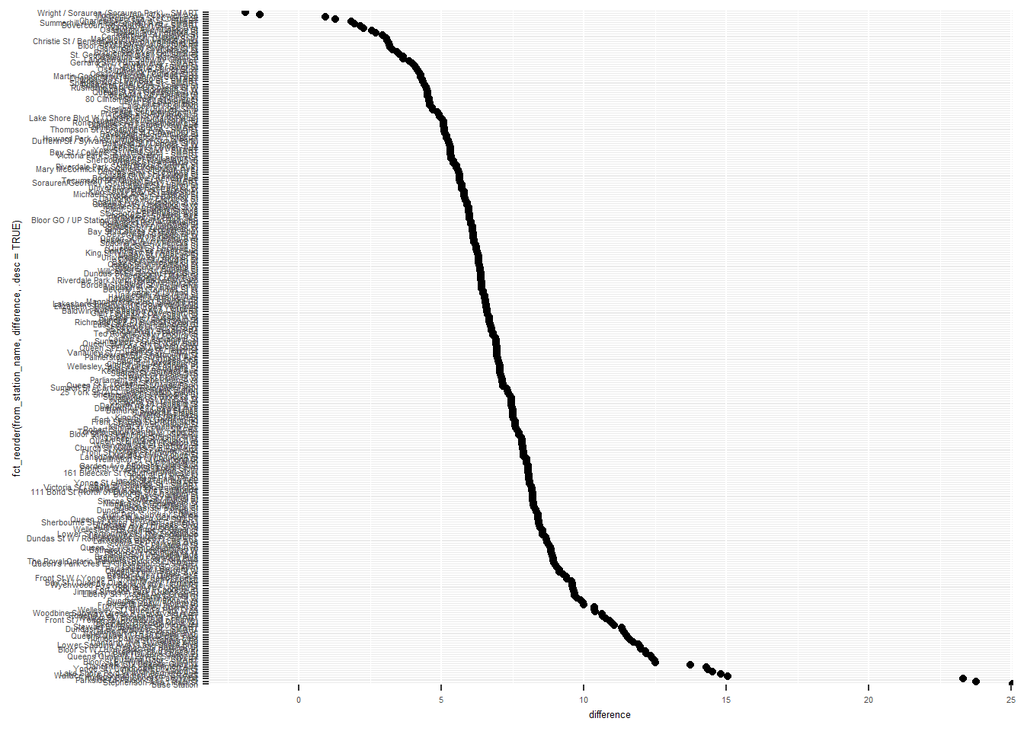

```r
 station_summary_user %>%
   ggplot(aes(fct_reorder(from_station_name,
                          difference, .desc = TRUE),
              difference)) +
   geom_point() +
   coord_flip() +
   theme(text = element_text(size=5))
```

Fixing the station names and adding distance between stations

```r
# download the station id data --------------------------------------------

# different ways of extracting data from an API in R

# extract json
station_info <- jsonlite::fromJSON('https://tor.publicbikesystem.net/ube/gbfs/v1/en/station_information')

# with GET
station_info_get <- GET('https://tor.publicbikesystem.net/ube/gbfs/v1/en/station_information')
station_info_get <- content(station_info_get)
station_info_get <- station_info_get$data$station # this returns a list object

station_info$data$stations

from_data <- station_info$data$stations %>%
  select(from_id = station_id,
         from_name= name,
         from_lat = lat, from_lon = lon) %>%
  as_tibble()

to_data <- station_info$data$stations %>%
  select(to_id = station_id,
         to_name= name,
         to_lat = lat,
         to_lon = lon) %>%
  as_tibble()

# join station info -------------------------------------------------------

###########################################################################
# FROM STATION
bike_good <- bike %>%
  inner_join(from_data, by = c('from_station_name' = 'from_name'))

bike_bad <- bike %>%
  anti_join(from_data, by = c('from_station_name' = 'from_name'))

bike_bad_good <- bike_bad %>%
  stringdist_inner_join(from_data, by = c('from_station_name' = 'from_name'),
                        max_dist = 15, distance_col = "dist") %>%
  group_by(trip_id) %>%
  arrange(dist) %>%
  filter(row_number() == 1) %>%
  ungroup()

bike_bad <- bike_bad %>%
  stringdist_anti_join(from_data, by = c('from_station_name' = 'from_name'),
                       max_dist = 15, distance_col = "dist")


bike <- bike_good %>%
  bind_rows(bike_bad_good)
################################################################################


###########################################################################
# TO STATION
bike_good <- bike %>%
  inner_join(to_data, by = c('to_station_name' = 'to_name'))

bike_bad <- bike %>%
  anti_join(to_data, by = c('to_station_name' = 'to_name'))

bike_bad_good <- bike_bad %>%
  stringdist_inner_join(to_data, by = c('to_station_name' = 'to_name'),
                        max_dist = 15, distance_col = "dist_to") %>%
  group_by(trip_id) %>%
  arrange(dist_to) %>%
  filter(row_number() == 1) %>%
  ungroup()

bike <- bike_good %>%
  bind_rows(bike_bad_good)
################################################################################



library(geosphere)

# calculate distance in km

bike <- bike %>%
  rowwise() %>%
  mutate(distance = distHaversine(c(from_lon,
                                    from_lat),
                                  c(to_lon,
                                    to_lat))) %>%
  ungroup()
```

### Exploring distance

The distance traveled by casual users and members doesn’t seem to be any different.

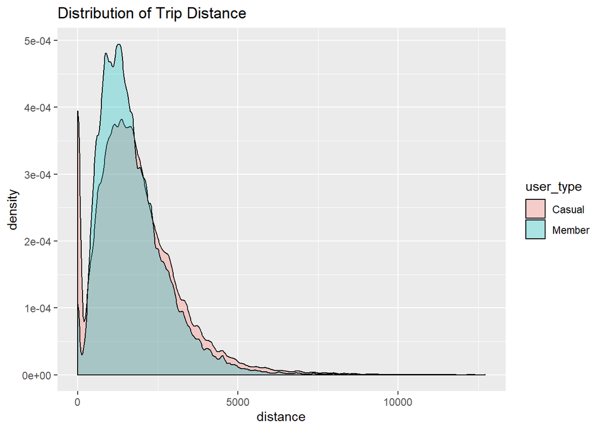

```r
bike %>%
  ggplot(aes(distance, fill = user_type)) +
  geom_density(alpha = .3) +
  ggtitle("Distribution of Trip Distance")
```

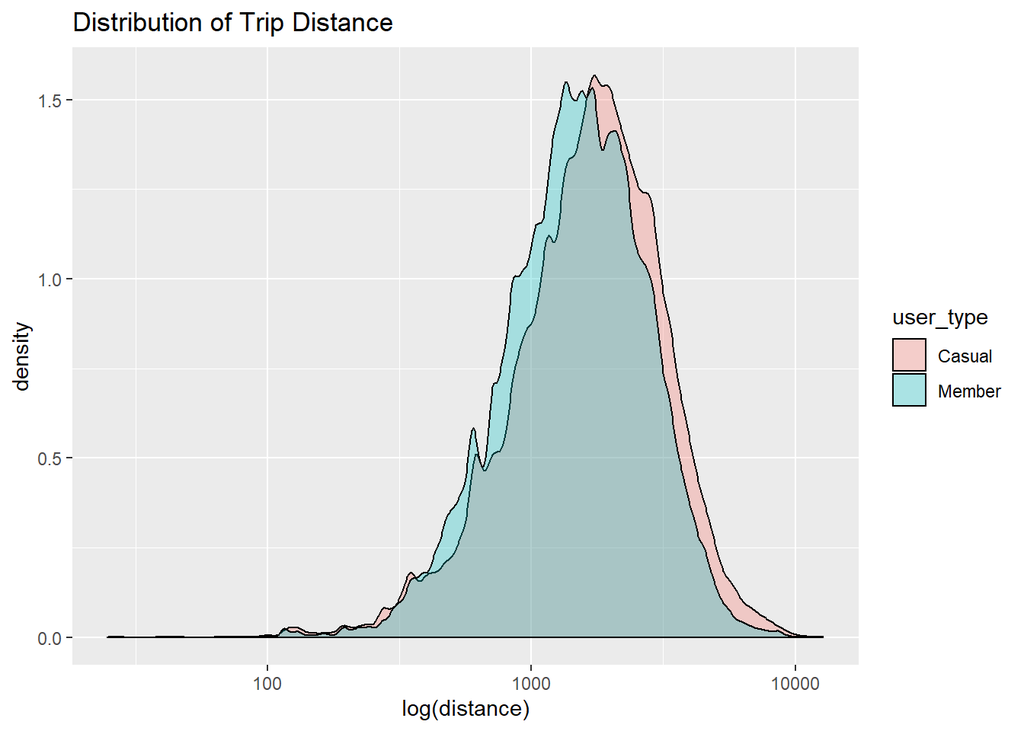

```r
bike %>%
  ggplot(aes(distance, fill = user_type)) +
  geom_density(alpha = .3) +
  ggtitle("Distribution of Trip Distance") +
  xlab("log(distance)") +
  scale_x_log10()
```

### Create date features

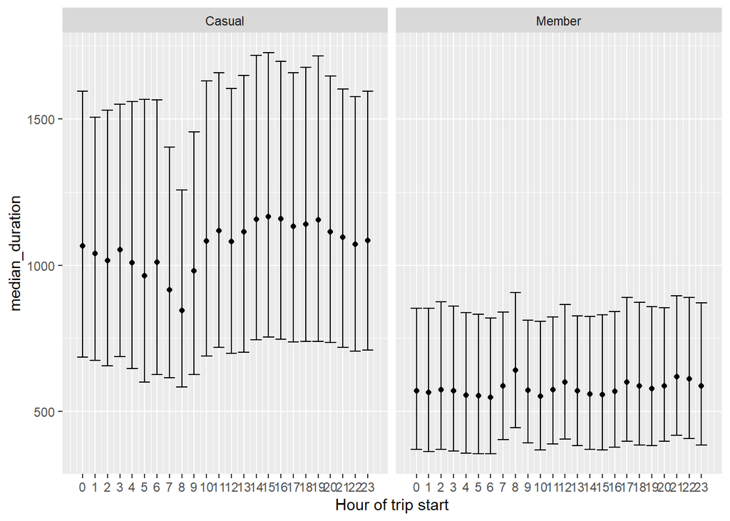

```r
bike <- bike %>%
  mutate(hour_start = hour(trip_start_time),
         day_start = wday(trip_start_time, label = T),
         month_start = month(trip_start_time),
         week = week(trip_start_time))


bike %>%
  group_by(hour_start, user_type) %>%
  summarize(median_duration = median(trip_duration_seconds),
            q25_duration = quantile(trip_duration_seconds, .25),
             q75_duration = quantile(trip_duration_seconds, .75)) %>%
  ggplot(aes(hour_start, median_duration)) +
  geom_point() +
    geom_errorbar(aes(ymin = q25_duration, ymax = q75_duration)) +
  xlab("Hour of trip start") +
    facet_grid(~user_type) +
  scale_x_continuous(breaks = 0:23)
```

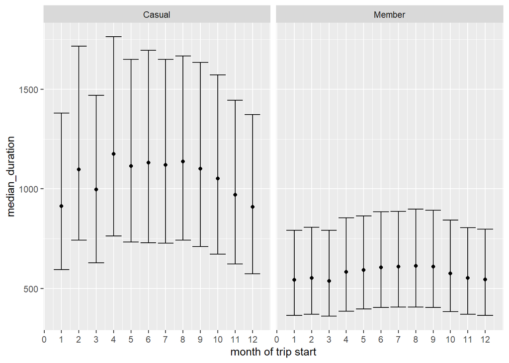

```r
bike %>%
  group_by(month_start, user_type) %>%
  summarize(median_duration = median(trip_duration_seconds),
            q25_duration = quantile(trip_duration_seconds, .25),
             q75_duration = quantile(trip_duration_seconds, .75)) %>%
  ggplot(aes(month_start, median_duration)) +
  geom_point() +
    geom_errorbar(aes(ymin = q25_duration, ymax = q75_duration)) +
  xlab("month of trip start") +
    facet_grid(~user_type) +
  scale_x_continuous(breaks = 0:12)
```

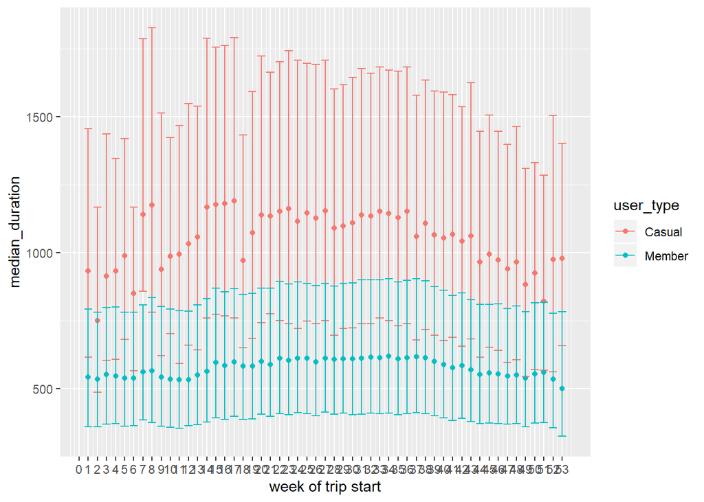

```r
bike %>%
  group_by(week, user_type) %>%
  summarize(median_duration = median(trip_duration_seconds),
            q25_duration = quantile(trip_duration_seconds, .25),
             q75_duration = quantile(trip_duration_seconds, .75)) %>%
  ggplot(aes(week, median_duration, color = user_type)) +
  geom_point() +
    geom_errorbar(aes(ymin = q25_duration, ymax = q75_duration)) +
  xlab("week of trip start") +
  scale_x_continuous(breaks = 0:53)
```

2. Do casual users take shorter trips compared to members? Is it possible to identify if bikes are being used by tourists or residents?

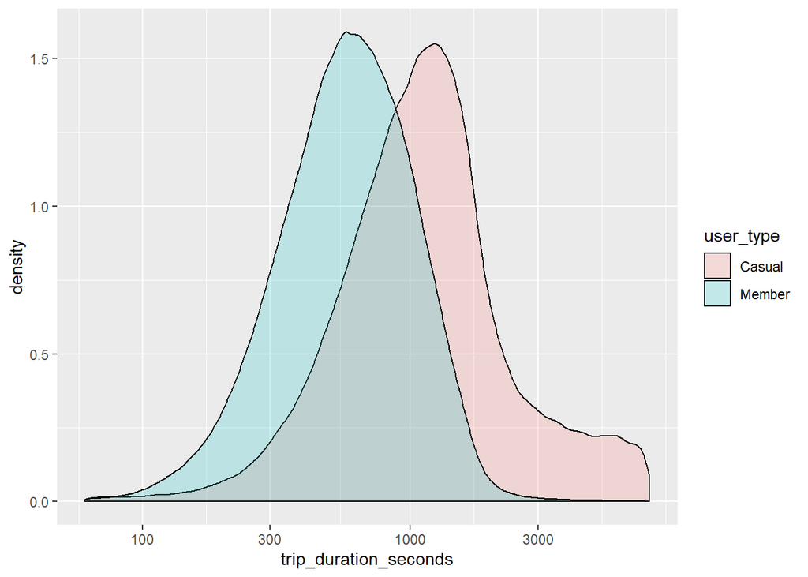

```r
bike %>%
  ggplot(aes(trip_duration_seconds, fill = user_type)) +
  geom_density(alpha = .2) +
  scale_x_log10()
```

```r
bike %>%
  group_by(user_type) %>%
  summarize(mean_trip_duration = round(mean(trip_duration_seconds/60), 3),
            sd_trip_duration = round(sd(trip_duration_seconds/60), 3),
            median_duration = round(median(trip_duration_seconds/60), 3),
            q25_duration = round(quantile(trip_duration_seconds/60, .25), 3),
            q75_duration = round(quantile(trip_duration_seconds/60, .75), 3)) %>%
  DT::datatable(caption = "Summary of trip duration by user type in minutes")
```

|  | user_type | mean_trip_duration | sd_trip_duration | median_duration | q25_duration | q75_duration |
| --- | --- | --- | --- | --- | --- | --- |
| 1 | Casual | 24.562 | 21.695 | 18.467 | 11.933 | 27.3 |
| 2 | Member | 11.153 | 6.795 | 9.783 | 6.533 | 14.317 |

It looks like members take shorter trips than casual users (median = 18.4 vs 9.78 minutes). From plots above it seems that trip behaviour is a little different between the two groups. We will attempt a regression model to control for a couple of factors.

```r
# recode station names with low counts to other

station_count <- bike %>%
  count(from_station_name, user_type) %>%
  filter(n < 3000)

other_stations <- unique(station_count$from_station_name)

bike <- bike %>%
  mutate(station_refactor = ifelse(from_station_name %in% other_stations, "other",
                                   from_station_name))

user_model <- lm(trip_duration_seconds ~ user_type +
                   month_start +day_start + station_refactor, data = bike)

coefs <- broom::tidy(user_model)

coefs %>% slice(2) %>%
  knitr::kable()
```

| term | estimate | std.error | statistic | p.value |
| --- | --- | --- | --- | --- |
| user_typeMember | -763.826 | 1.273297 | -599.8806 | 0 |

3. Does season or weather affect trip duration or distance?

Below are the functions required to scrape weather data from the government of Canada website:

```r
clean_var_names <- function(x) {

  clean_x <- tolower(x) %>%
    str_replace_all(., "/|\'|°", "") %>%
    str_replace_all(., " ", "_")

  return(clean_x)
}





scrape_weather <- function(station = "51459",
                           year = 2017,
                           month = 3) {

  # the url to query
  query_url <- glue::glue('http://climate.weather.gc.ca/climate_data/daily_data_e.html?StationID={station}&timeframe=2&Year={year}&Month={month}#')

  # read in the table
  weather_data <- query_url %>%
    read_html() %>%
    html_table() %>%
    .[[1]]

  # clean up the names of the weather variables
  names(weather_data) <- clean_var_names(names(weather_data))

  # create dates and remove summary stats rows (i.e. where date is missing)
  weather_data <- weather_data %>%
    mutate(date = ymd(paste(year, month, day, '-'))) %>%
    select(date, mean_temp_definitionc, total_precip_definitionmm) %>%
    filter(!is.na(date))

  # transform weather variables to numeric
  # replace LegendTT with some small value
  weather_data <- weather_data %>%
    mutate(total_precip = as.numeric(ifelse(total_precip_definitionmm == "LegendTT",
                                            "0.01",total_precip_definitionmm)),
           total_precip = ifelse(is.na(total_precip), 0, total_precip),
           mean_temp = as.numeric(mean_temp_definitionc)) %>%
    select(date, mean_temp, total_precip)

  return(weather_data)

}
```

We extract the weather for 2016 and 2017 separately and merge them together

```r
# get weather for 2016
months <- 1:12
weather2016 <- list()
for(i in months[7:12]) {
  weather2016[[i]] <- scrape_weather(month = i, year = 2016)
}


# get weather for 2017
weather2017 <- list()
for(i in months) {
  weather2017[[i]] <- scrape_weather(month = i, year = 2017)
}

# join lists together
weather2016 <- do.call(rbind, weather2016)
weather2017 <- do.call(rbind, weather2017)

weather <- weather2016 %>%
  bind_rows(weather2017)

# join the weather data to the bike data

# dim before joining weather data
dim(bike)
```

```
## [1] 1962131      25
```

```r
bike <- bike %>%
  mutate(date = as_date(trip_start_time)) %>%
  left_join(weather, by = "date") %>%
  filter(!is.na(mean_temp))

# dim after joining weather data
dim(bike)
```

```
## [1] 1945593      28
```

```r
# mean trip duration by different weather
bike %>%
  filter(!is.na(mean_temp)) %>%
  mutate(mean_temp_cut = cut(mean_temp, 10)) %>%
  group_by(mean_temp_cut) %>%
  summarize(mean_duration = mean(trip_duration_seconds))
```

```
## # A tibble: 10 x 2
##    mean_temp_cut mean_duration
##    <fct>                 <dbl>
##  1 (-18.6,-13.7]          629.
##  2 (-13.7,-8.78]          621.
##  3 (-8.78,-3.87]          635.
##  4 (-3.87,1.04]           636.
##  5 (1.04,5.95]            663.
##  6 (5.95,10.9]            742.
##  7 (10.9,15.8]            818.
##  8 (15.8,20.7]            897.
##  9 (20.7,25.6]            935.
## 10 (25.6,30.5]            889.
```

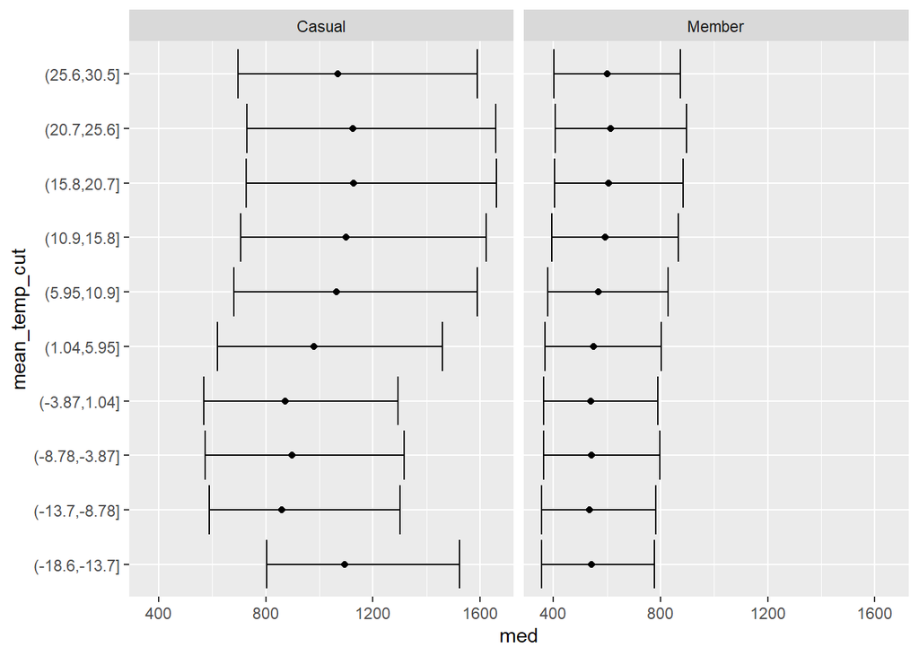

```r
bike %>%
  filter(!is.na(mean_temp)) %>%
  mutate(mean_temp_cut = cut(mean_temp, 10)) %>%
  group_by(mean_temp_cut, user_type) %>%
  summarize(med = median(trip_duration_seconds),
            q25 = quantile(trip_duration_seconds, .25),
            q75 = quantile(trip_duration_seconds, .75)) %>%
  ggplot(aes(mean_temp_cut, med)) +
  geom_point() +
  geom_errorbar(aes(ymin = q25, ymax = q75)) + coord_flip() +
  facet_grid(~ user_type)
```

```r
weather_model <- lm(trip_duration_seconds ~ mean_temp  + factor(month_start ), data = bike)
weather_model_distance <- lm(distance ~ mean_temp  + factor(month_start ), data = bike)

library(pander)

pander( summary(weather_model) )
```

|  | Estimate | Std. Error | t value | Pr(>\|t\|) |
| --- | --- | --- | --- | --- |
| **(Intercept)** | 639.4 | 3.767 | 169.8 | 0 |
| **mean_temp** | 3.903 | 0.1376 | 28.37 | 4.584e-177 |
| **factor(month_start)2** | 44.06 | 5.323 | 8.276 | 1.277e-16 |
| **factor(month_start)3** | 4.975 | 5.114 | 0.9729 | 0.3306 |
| **factor(month_start)4** | 145 | 4.903 | 29.57 | 3.704e-192 |
| **factor(month_start)5** | 129.9 | 4.886 | 26.58 | 1.153e-155 |
| **factor(month_start)6** | 166.1 | 5.117 | 32.46 | 4.522e-231 |
| **factor(month_start)7** | 241.7 | 5.152 | 46.91 | 0 |
| **factor(month_start)8** | 213.8 | 5.059 | 42.27 | 0 |
| **factor(month_start)9** | 160.8 | 4.854 | 33.12 | 1.585e-240 |
| **factor(month_start)10** | 77.28 | 4.481 | 17.25 | 1.195e-66 |
| **factor(month_start)11** | 10.21 | 4.242 | 2.406 | 0.01614 |
| **factor(month_start)12** | 9.856 | 4.51 | 2.185 | 0.02886 |

Fitting linear model: trip_duration_seconds ~ mean_temp + factor(month_start)

| Observations | Residual Std. Error | $R^2$ | Adjusted $R^2$ |
| --- | --- | --- | --- |
| 1945593 | 758.3 | 0.0209 | 0.0209 |

```r
pander(summary(weather_model_distance))
```

|  | Estimate | Std. Error | t value | Pr(>\|t\|) |
| --- | --- | --- | --- | --- |
| **(Intercept)** | 1604 | 5.527 | 290.2 | 0 |
| **mean_temp** | 1.544 | 0.2019 | 7.648 | 2.045e-14 |
| **factor(month_start)2** | 4.018 | 7.812 | 0.5143 | 0.607 |
| **factor(month_start)3** | 13 | 7.504 | 1.733 | 0.08317 |
| **factor(month_start)4** | 77.14 | 7.195 | 10.72 | 8.077e-27 |
| **factor(month_start)5** | 92.42 | 7.17 | 12.89 | 5.172e-38 |
| **factor(month_start)6** | 98.47 | 7.509 | 13.11 | 2.757e-39 |
| **factor(month_start)7** | 73.62 | 7.561 | 9.737 | 2.1e-22 |
| **factor(month_start)8** | 150.2 | 7.424 | 20.23 | 5.183e-91 |
| **factor(month_start)9** | 152.3 | 7.124 | 21.38 | 1.923e-101 |
| **factor(month_start)10** | 94.09 | 6.575 | 14.31 | 1.943e-46 |
| **factor(month_start)11** | 55.49 | 6.225 | 8.914 | 4.927e-19 |
| **factor(month_start)12** | 20 | 6.618 | 3.022 | 0.002514 |

Fitting linear model: distance ~ mean_temp + factor(month_start)

| Observations | Residual Std. Error | $R^2$ | Adjusted $R^2$ |
| --- | --- | --- | --- |
| 1945593 | 1113 | 0.002501 | 0.002495 |

4. Define trip length in two ways, and create feature variables in the data set. What factors affect trip length? Do these factors differ depending on your definition?

Trip length has been defined as duration and trip distance. Yes, for one there is little difference in distance by user type. see plots throughout

5. Use linear regression to build a prediction model of trip length.

```r
# set seed for reproducibility
set.seed(3399)

###############################################################################
# recode station name
station_count <- bike %>%
  count(from_station_name, user_type) %>%
  filter(n < 2000)

other_stations <- unique(station_count$from_station_name)

bike <- bike %>%
  mutate(station_refactor = ifelse(from_station_name %in% other_stations,
                                   "other",
                                   from_station_name))
###############################################################################

# split the data into a training and testing set
split_size <- .3
n <- nrow(bike)

# randomly sample the training rows
training_rows <- sample(1:n, size = floor(split_size*n), replace = F)

# the training data
train_df <- bike %>%
  slice(training_rows)

# the testing data
test_df <- bike %>%
  slice(-training_rows)

# a baseline model for comparison
baseline_model <- lm(log(trip_duration_seconds) ~ 1, data = train_df)

# a full model with interactions
full_model <- lm(log(trip_duration_seconds) ~ user_type +
                   station_refactor+
                   station_refactor*user_type+
                   mean_temp +
                   day_start +
                   user_type*mean_temp +
                   total_precip +
                   factor(hour_start) +
                   factor(hour_start)*user_type
                   , data = train_df)

sum_results <- broom::tidy(full_model)

DT::datatable(sum_results, caption = "Model coefficients")
```

|  | term | estimate | std.error | statistic | p.value |
| --- | --- | --- | --- | --- | --- |
| 1 | (Intercept) | 6.99903194212571 | 0.0230748173290536 | 303.319061742396 | 0 |
| 2 | user_typeMember | -0.505680655319003 | 0.0279588324825249 | -18.0866155850774 | 4.2545727987782e-73 |
| 3 | station_refactorAugusta Ave / Denison Sq | -0.14298217473916 | 0.0259327404154942 | -5.51357752587271 | 3.51760332077455e-08 |
| 4 | station_refactorAugusta Ave / Dundas St W | -0.213368590149906 | 0.0263652450372218 | -8.09279753890692 | 5.84202494404024e-16 |
| 5 | station_refactorBathurst St / Dundas St W | -0.290985607344239 | 0.029896068786157 | -9.73323982579865 | 2.18407016353873e-22 |
| 6 | station_refactorBathurst St / Fort York Blvd | -0.0509708233656669 | 0.0315352174780538 | -1.61631431275649 | 0.10602691446304 |
| 7 | station_refactorBathurst St / Queens Quay W | 0.0337465672315988 | 0.0301415067577533 | 1.11960452086285 | 0.26288278907424 |
| 8 | station_refactorBay St / Albert St | -0.175348671322155 | 0.0255266891490012 | -6.86922891952935 | 6.46140450724429e-12 |
| 9 | station_refactorBay St / Bloor St W | -0.153880045235631 | 0.0298883413609705 | -5.14849731462766 | 2.62666481433472e-07 |
| 10 | station_refactorBay St / College St (East Side) | -0.262536321026934 | 0.0309859884545834 | -8.47274313716787 | 2.40225146476649e-17 |

[output cut: 169 more lines]

```r
train_df <- train_df %>%
  mutate(prediction_full = exp(predict(full_model, train_df)),
         prediction_baseline = exp(predict(baseline_model, train_df)))

test_df <- test_df %>%
  mutate(prediction_full = exp(predict(full_model, test_df)),
         prediction_baseline = exp(predict(baseline_model, test_df)))




rmse <- function(actual, predicted) {

  rmse_val <- sqrt(mean((actual - predicted)^2, na.rm = T))
}

train_rmse_full <- rmse(train_df$trip_duration_seconds, train_df$prediction_full)
test_rmse_full <- rmse(test_df$trip_duration_seconds, test_df$prediction_full)

train_rmse_baseline <- rmse(train_df$trip_duration_seconds, train_df$prediction_baseline)
test_rmse_baseline <- rmse(test_df$trip_duration_seconds, test_df$prediction_baseline)


summary_results <- tibble(split = c("train", "test"),
                          baseline_model = c(train_rmse_baseline,test_rmse_baseline ),
                          full_model = c(train_rmse_full, test_rmse_full))

DT::datatable(summary_results)
```

|  | split | baseline_model | full_model |
| --- | --- | --- | --- |
| 1 | train | 784.510579046845 | 704.577033345769 |
| 2 | test | 789.168093187742 | 709.601115433316 |